HW #1: Flat files, RDB, and merging / aggregating

**Data Wrangling**  
**ANLT 224**  
**Febuary 26, 2018**

By: Ali Taheri

# Reading frm flat file

At this assignment, we want to exercise working with flat files and databases. Firstly we have a CSV file that has been downloaded from IMDB about 1000 movies from 2006 to 2016. We read this CSV file to a pandas dataframe and would have some exploratory analysis on it.

```python
import pandas as pd

#import data into a pandas dataframe and view the first 5 rows
movies_df = pd.read_csv('IMDB-Movie-Data.csv')
movies_df.head(3)
```

|  | Rank | Title | Genre | Description | Director | Actors | Year | Runtime (Minutes) | Rating | Votes | Revenue (Millions) | Metascore |
| --- | --- | --- | --- | --- | --- | --- | --- | --- | --- | --- | --- | --- |
| 0 | 1 | Guardians of the Galaxy | Action,Adventure,Sci-Fi | A group of intergalactic criminals are forced ... | James Gunn | Chris Pratt, Vin Diesel, Bradley Cooper, Zoe S... | 2014 | 121 | 8.1 | 757074 | 333.13 | 76.0 |
| 1 | 2 | Prometheus | Adventure,Mystery,Sci-Fi | Following clues to the origin of mankind, a te... | Ridley Scott | Noomi Rapace, Logan Marshall-Green, Michael Fa... | 2012 | 124 | 7.0 | 485820 | 126.46 | 65.0 |
| 2 | 3 | Split | Horror,Thriller | Three girls are kidnapped by a man with a diag... | M. Night Shyamalan | James McAvoy, Anya Taylor-Joy, Haley Lu Richar... | 2016 | 117 | 7.3 | 157606 | 138.12 | 62.0 |

```python
#Summary of dataframe
movies_df.describe()
```

|  | Rank | Year | Runtime (Minutes) | Rating | Votes | Revenue (Millions) | Metascore |
| --- | --- | --- | --- | --- | --- | --- | --- |
| count | 1000.000000 | 1000.000000 | 1000.000000 | 1000.000000 | 1.000000e+03 | 872.000000 | 936.000000 |
| mean | 500.500000 | 2012.783000 | 113.172000 | 6.723200 | 1.698083e+05 | 82.956376 | 58.985043 |
| std | 288.819436 | 3.205962 | 18.810908 | 0.945429 | 1.887626e+05 | 103.253540 | 17.194757 |
| min | 1.000000 | 2006.000000 | 66.000000 | 1.900000 | 6.100000e+01 | 0.000000 | 11.000000 |
| 25% | 250.750000 | 2010.000000 | 100.000000 | 6.200000 | 3.630900e+04 | 13.270000 | 47.000000 |
| 50% | 500.500000 | 2014.000000 | 111.000000 | 6.800000 | 1.107990e+05 | 47.985000 | 59.500000 |
| 75% | 750.250000 | 2016.000000 | 123.000000 | 7.400000 | 2.399098e+05 | 113.715000 | 72.000000 |
| max | 1000.000000 | 2016.000000 | 191.000000 | 9.000000 | 1.791916e+06 | 936.630000 | 100.000000 |

We can see that average rating of these movies is 6.7 and average revenue is 82 million USD. It shows that these movies are very good movies of Hollywood that must be seen definitely.

```python
#Dimension of dataset
movies_df.shape
```

```
(1000, 12)
```

We can see that this dataset has 1000 rows that each row represents 12 features of a movie.  
At first, we would see number of movies per each year.

```
Text(0.5,1,'Movie Count by Year')
```

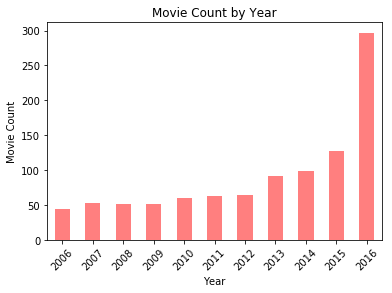

```python
#Determine number of movies that were produced each year
movie_yearly_count = movies_df['Year'].value_counts().sort_index().plot(kind='bar', color='r', alpha=0.5, grid=False, rot=45)
movie_yearly_count.set_xlabel('Year')
movie_yearly_count.set_ylabel('Movie Count')
movie_yearly_count.set_title('Movie Count by Year')
```

# Reading from Database

At this phase we would read from sakila database. We would fetch table of film, actor and film_actor for some processes. At first, we import required module and will set different parameters for access to database.

```python
import pymysql as mydb
```

```python
u_id = "anlt224-student"
password = "data-wrangling"
db_name = "sakila"
server = "ec2-34-214-90-230.us-west-2.compute.amazonaws.com"
port = 3306
```

We will now make a connection to database and assign it to a variable.

```python
db_conn = mydb.connect(host=server, user=u_id, passwd=password, db=db_name, port=port)
```

```python
#Reading film table from database
film_df = pd.read_sql("SELECT * FROM film ;", db_conn)
film_df.head(3)
```

|  | film_id | title | description | release_year | language_id | original_language_id | rental_duration | rental_rate | length | replacement_cost | rating | special_features | last_update |
| --- | --- | --- | --- | --- | --- | --- | --- | --- | --- | --- | --- | --- | --- |
| 0 | 1 | ACADEMY DINOSAUR | A Epic Drama of a Feminist And a Mad Scientist... | 2006 | 1 | None | 6 | 0.99 | 86 | 20.99 | PG | Deleted Scenes,Behind the Scenes | 2006-02-15 05:03:42 |
| 1 | 2 | ACE GOLDFINGER | A Astounding Epistle of a Database Administrat... | 2006 | 1 | None | 3 | 4.99 | 48 | 12.99 | G | Trailers,Deleted Scenes | 2006-02-15 05:03:42 |
| 2 | 3 | ADAPTATION HOLES | A Astounding Reflection of a Lumberjack And a ... | 2006 | 1 | None | 7 | 2.99 | 50 | 18.99 | NC-17 | Trailers,Deleted Scenes | 2006-02-15 05:03:42 |

```python
film_df.describe()
```

|  | film_id | release_year | language_id | rental_duration | rental_rate | length | replacement_cost |
| --- | --- | --- | --- | --- | --- | --- | --- |
| count | 1000.000000 | 1000.0 | 1000.0 | 1000.000000 | 1000.000000 | 1000.000000 | 1000.000000 |
| mean | 500.500000 | 2006.0 | 1.0 | 4.985000 | 2.980000 | 115.272000 | 19.984000 |
| std | 288.819436 | 0.0 | 0.0 | 1.411654 | 1.646393 | 40.426332 | 6.050833 |
| min | 1.000000 | 2006.0 | 1.0 | 3.000000 | 0.990000 | 46.000000 | 9.990000 |
| 25% | 250.750000 | 2006.0 | 1.0 | 4.000000 | 0.990000 | 80.000000 | 14.990000 |
| 50% | 500.500000 | 2006.0 | 1.0 | 5.000000 | 2.990000 | 114.000000 | 19.990000 |
| 75% | 750.250000 | 2006.0 | 1.0 | 6.000000 | 4.990000 | 149.250000 | 24.990000 |
| max | 1000.000000 | 2006.0 | 1.0 | 7.000000 | 4.990000 | 185.000000 | 29.990000 |

We can see that all movies are for year of 2006 and their average duration is 115 minutes.

```python
film_df.shape
```

```
(1000, 13)
```

Second table is actor table.

```python
actor_df = pd.read_sql("SELECT * FROM actor ;", db_conn)
actor_df.head()
```

|  | actor_id | first_name | last_name | last_update |
| --- | --- | --- | --- | --- |
| 0 | 1 | PENELOPE | GUINESS | 2006-02-15 04:34:33 |
| 1 | 2 | NICK | WAHLBERG | 2006-02-15 04:34:33 |
| 2 | 3 | ED | CHASE | 2006-02-15 04:34:33 |
| 3 | 4 | JENNIFER | DAVIS | 2006-02-15 04:34:33 |
| 4 | 5 | JOHNNY | LOLLOBRIGIDA | 2006-02-15 04:34:33 |

And fina table is film_actor table.

```python
film_actor_df = pd.read_sql("SELECT * FROM film_actor ;", db_conn)
film_actor_df.head()
```

|  | actor_id | film_id | last_update |
| --- | --- | --- | --- |
| 0 | 1 | 1 | 2006-02-15 05:05:03 |
| 1 | 1 | 23 | 2006-02-15 05:05:03 |
| 2 | 1 | 25 | 2006-02-15 05:05:03 |
| 3 | 1 | 106 | 2006-02-15 05:05:03 |
| 4 | 1 | 140 | 2006-02-15 05:05:03 |

Firstly, we merge actor and film_actor tables by field of actor_id. We would select important columns.

```python
filmactor_actor_df=pd.merge(actor_df,film_actor_df,left_on= 'actor_id', right_on= 'actor_id')
filmactor_actor_df=filmactor_actor_df[['first_name','last_name','film_id']]
filmactor_actor_df.head()
```

|  | first_name | last_name | film_id |
| --- | --- | --- | --- |
| 0 | PENELOPE | GUINESS | 1 |
| 1 | PENELOPE | GUINESS | 23 |
| 2 | PENELOPE | GUINESS | 25 |
| 3 | PENELOPE | GUINESS | 106 |
| 4 | PENELOPE | GUINESS | 140 |

Next, we will merge film and film_actor tables and capitalize first_name and last_name of actors and put complete name in a new column with name of Actor as below. We remove some columns which we are not interested about them now.

```python
film_actor_df=pd.merge(film_df,filmactor_actor_df)
film_actor_df['first_name']=film_actor_df['first_name'].apply(lambda x: x.capitalize())
film_actor_df['last_name']=film_actor_df['last_name'].apply(lambda x: x.capitalize())
film_actor_df['Actor']= film_actor_df['first_name']+' '+film_actor_df['last_name']
film_actor_df=film_actor_df.drop(columns=['first_name','last_name','film_id','last_update'])
film_actor_df.head(3)
```

|  | title | description | release_year | language_id | original_language_id | rental_duration | rental_rate | length | replacement_cost | rating | special_features | Actor |
| --- | --- | --- | --- | --- | --- | --- | --- | --- | --- | --- | --- | --- |
| 0 | ACADEMY DINOSAUR | A Epic Drama of a Feminist And a Mad Scientist... | 2006 | 1 | None | 6 | 0.99 | 86 | 20.99 | PG | Deleted Scenes,Behind the Scenes | Penelope Guiness |
| 1 | ACADEMY DINOSAUR | A Epic Drama of a Feminist And a Mad Scientist... | 2006 | 1 | None | 6 | 0.99 | 86 | 20.99 | PG | Deleted Scenes,Behind the Scenes | Christian Gable |
| 2 | ACADEMY DINOSAUR | A Epic Drama of a Feminist And a Mad Scientist... | 2006 | 1 | None | 6 | 0.99 | 86 | 20.99 | PG | Deleted Scenes,Behind the Scenes | Lucille Tracy |

Now, we combine all actors of a movie with comma separator and make a series of them with index of movie title.

```python
actors_of_movie=film_actor_df.groupby(['title'])['Actor'].apply(lambda x: "%s" % ', '.join(x))
```

Then, we remove duplicated rows of each movie, remove Actor column and put all actors of a movie in a new column with name of Actors.

```python
film_actor_df=film_actor_df.drop_duplicates(subset='title', keep="last")
film_actor_df=film_actor_df.drop(columns=['Actor'])
film_actor_df['Actors']=film_actor_df['title'].apply(lambda x: actors_of_movie[x])
film_actor_df.head(3)
```

|  | title | description | release_year | language_id | original_language_id | rental_duration | rental_rate | length | replacement_cost | rating | special_features | Actors |
| --- | --- | --- | --- | --- | --- | --- | --- | --- | --- | --- | --- | --- |
| 9 | ACADEMY DINOSAUR | A Epic Drama of a Feminist And a Mad Scientist... | 2006 | 1 | None | 6 | 0.99 | 86 | 20.99 | PG | Deleted Scenes,Behind the Scenes | Penelope Guiness, Christian Gable, Lucille Tra... |
| 13 | ACE GOLDFINGER | A Astounding Epistle of a Database Administrat... | 2006 | 1 | None | 3 | 4.99 | 48 | 12.99 | G | Trailers,Deleted Scenes | Bob Fawcett, Minnie Zellweger, Sean Guiness, C... |
| 18 | ADAPTATION HOLES | A Astounding Reflection of a Lumberjack And a ... | 2006 | 1 | None | 7 | 2.99 | 50 | 18.99 | NC-17 | Trailers,Deleted Scenes | Nick Wahlberg, Bob Fawcett, Cameron Streep, Ra... |

```python
#Re-indexing new dataframe
film_actor_df.index=range(len(film_actor_df['title']))
film_actor_df.head(3)
```

|  | title | description | release_year | language_id | original_language_id | rental_duration | rental_rate | length | replacement_cost | rating | special_features | Actors |
| --- | --- | --- | --- | --- | --- | --- | --- | --- | --- | --- | --- | --- |
| 0 | ACADEMY DINOSAUR | A Epic Drama of a Feminist And a Mad Scientist... | 2006 | 1 | None | 6 | 0.99 | 86 | 20.99 | PG | Deleted Scenes,Behind the Scenes | Penelope Guiness, Christian Gable, Lucille Tra... |
| 1 | ACE GOLDFINGER | A Astounding Epistle of a Database Administrat... | 2006 | 1 | None | 3 | 4.99 | 48 | 12.99 | G | Trailers,Deleted Scenes | Bob Fawcett, Minnie Zellweger, Sean Guiness, C... |
| 2 | ADAPTATION HOLES | A Astounding Reflection of a Lumberjack And a ... | 2006 | 1 | None | 7 | 2.99 | 50 | 18.99 | NC-17 | Trailers,Deleted Scenes | Nick Wahlberg, Bob Fawcett, Cameron Streep, Ra... |

For further actions and for more clarification, we would select some columns, rename some of them and finally reorder them.

```python
film_actor_df=film_actor_df[['title','description','release_year','length','special_features','rating','Actors']]
film_actor_df.rename( columns={'title': 'Title','description':'Description','release_year':'Year','length':'Runtime (Minutes)',
                           'special_features':'Genre'}, inplace=True)
film_actor_df=film_actor_df[['Title','Genre','Description','Year','Runtime (Minutes)','rating','Actors']]
film_actor_df.head(3)
```

|  | Title | Genre | Description | Year | Runtime (Minutes) | rating | Actors |
| --- | --- | --- | --- | --- | --- | --- | --- |
| 0 | ACADEMY DINOSAUR | Deleted Scenes,Behind the Scenes | A Epic Drama of a Feminist And a Mad Scientist... | 2006 | 86 | PG | Penelope Guiness, Christian Gable, Lucille Tra... |
| 1 | ACE GOLDFINGER | Trailers,Deleted Scenes | A Astounding Epistle of a Database Administrat... | 2006 | 48 | G | Bob Fawcett, Minnie Zellweger, Sean Guiness, C... |
| 2 | ADAPTATION HOLES | Trailers,Deleted Scenes | A Astounding Reflection of a Lumberjack And a ... | 2006 | 50 | NC-17 | Nick Wahlberg, Bob Fawcett, Cameron Streep, Ra... |

```
Text(0.5,1,'Movie Count by Rating')
```

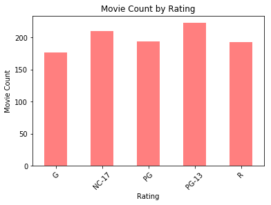

```python
#Determine number of movies per eacg rating
films_rating_count = film_actor_df['rating'].value_counts().sort_index().plot(kind='bar', color='r', alpha=0.5, grid=False, rot=45)
films_rating_count.set_xlabel('Rating')
films_rating_count.set_ylabel('Movie Count')
films_rating_count.set_title('Movie Count by Rating')
```

# Concatination and Writing to flat file and database

At this stage, we remove some not interested attributes of dataframe that has been read from flat file to be more similar with aggregated table from sakila database. Additionally we will change order of columns too.

```python
movies_df=movies_df.drop(['Rank', 'Rating','Votes','Revenue (Millions)','Metascore'], axis=1)
movies_df=movies_df[['Title','Genre','Description','Year','Runtime (Minutes)','Director','Actors']]
movies_df.head(3)
```

|  | Title | Genre | Description | Year | Runtime (Minutes) | Director | Actors |
| --- | --- | --- | --- | --- | --- | --- | --- |
| 0 | Guardians of the Galaxy | Action,Adventure,Sci-Fi | A group of intergalactic criminals are forced ... | 2014 | 121 | James Gunn | Chris Pratt, Vin Diesel, Bradley Cooper, Zoe S... |
| 1 | Prometheus | Adventure,Mystery,Sci-Fi | Following clues to the origin of mankind, a te... | 2012 | 124 | Ridley Scott | Noomi Rapace, Logan Marshall-Green, Michael Fa... |
| 2 | Split | Horror,Thriller | Three girls are kidnapped by a man with a diag... | 2016 | 117 | M. Night Shyamalan | James McAvoy, Anya Taylor-Joy, Haley Lu Richar... |

Now, we can merge our two databases by Title.

```python
df_result=pd.merge(movies_df,film_actor_df,left_on= 'Title', right_on= 'Title')
df_result
```

|  | Title | Genre_x | Description_x | Year_x | Runtime (Minutes)_x | Director | Actors_x | Genre_y | Description_y | Year_y | Runtime (Minutes)_y | rating | Actors_y |
| --- | --- | --- | --- | --- | --- | --- | --- | --- | --- | --- | --- | --- | --- |

We can see that thers is not any intersection on titles between two dataframes, so we will concat these two dataframes for make a dataframe with about 2000 movies.

```python
total_movies_df = pd.concat([film_actor_df, movies_df], ignore_index=True)
total_movies_df=total_movies_df[['Title','Description','Genre','Actors','Director','rating','Year','Runtime (Minutes)']]
total_movies_df.head(3)
```

|  | Title | Description | Genre | Actors | Director | rating | Year | Runtime (Minutes) |
| --- | --- | --- | --- | --- | --- | --- | --- | --- |
| 0 | ACADEMY DINOSAUR | A Epic Drama of a Feminist And a Mad Scientist... | Deleted Scenes,Behind the Scenes | Penelope Guiness, Christian Gable, Lucille Tra... | NaN | PG | 2006 | 86 |
| 1 | ACE GOLDFINGER | A Astounding Epistle of a Database Administrat... | Trailers,Deleted Scenes | Bob Fawcett, Minnie Zellweger, Sean Guiness, C... | NaN | G | 2006 | 48 |
| 2 | ADAPTATION HOLES | A Astounding Reflection of a Lumberjack And a ... | Trailers,Deleted Scenes | Nick Wahlberg, Bob Fawcett, Cameron Streep, Ra... | NaN | NC-17 | 2006 | 50 |

For example,we can find all movies that 'Tom Cruise' played at them.

```python
 total_movies_df[total_movies_df['Actors'].str.contains('Tom Cruise')][['Title']]
```

|  | Title |
| --- | --- |
| 1160 | Jack Reacher: Never Go Back |
| 1197 | Edge of Tomorrow |
| 1230 | Mission: Impossible - Rogue Nation |
| 1272 | Oblivion |
| 1430 | Mission: Impossible - Ghost Protocol |
| 1533 | Jack Reacher |
| 1866 | Mission: Impossible III |
| 1969 | Rock of Ages |

Now, we can write this total dataframe to a csv file.

```python
total_movies_df.to_csv('total_movie_data.csv')
```

At final stage, we will wite this dataframe to database of ANLT224 . we creat a writable cursor for writing on our database.

```python
writable_db = "ANLT224"
writable_conn = mydb.connect(host=server, user=u_id, passwd=password, db=writable_db, port=port)
writable_cursor = writable_conn.cursor()
```

We can see existing tables in ANLT224.

```python
writable_cursor.execute("SHOW TABLES;")
writable_cursor.fetchall()
```

```
(('MHFinalHW1',), ('mtcars_in_db',), ('my_temp',))
```

Following string is specification of our table in database.

```python
sql = '''
CREATE TABLE Total_Movies (
    ID INT NOT NULL AUTO_INCREMENT,
    Title VARCHAR(255) NOT NULL,
    Description VARCHAR(500) NOT NULL,
    Genre VARCHAR(255) NOT NULL,
    Actors VARCHAR(255) NOT NULL,
    Director VARCHAR(255),
    rating VARCHAR(255) NOT NULL,
    Year INT,
    Runtime INT,
    PRIMARY KEY (ID)
);
'''
```

By following line of code, table would be made in database

```python
writable_cursor.execute(sql)
```

```
0
```

```python
writable_cursor.execute("SHOW TABLES;")
writable_cursor.fetchall()
```

```
(('MHFinalHW1',), ('Total_Movies',), ('mtcars_in_db',), ('my_temp',))
```

You can see that we iterate on all tems of dataframe and write them in database as tuples.

```python
df=total_movies_df
df=df.fillna('NuLL')

for n in range(1996):
    row= (df.iloc[n,0],df.iloc[n,1],df.iloc[n,2],df.iloc[n,3],df.iloc[n,4],df.iloc[n,5],str(df.iloc[n,6]),
          str(df.iloc[n,7]))
    writable_cursor.execute('''INSERT INTO Total_Movies (Title, Description, Genre, Actors,Director,rating,Year, Runtime)
                               VALUES (%s, %s, %s, %s, %s, %s, %s, %s)''', row)
```

```python
writable_cursor.execute('SELECT * FROM Total_Movies LIMIT 3;')
writable_cursor.fetchall()
```

```
((1,
  'ACADEMY DINOSAUR',
  'A Epic Drama of a Feminist And a Mad Scientist who must Battle a Teacher in The Canadian Rockies',
  'Deleted Scenes,Behind the Scenes',
  'Penelope Guiness, Christian Gable, Lucille Tracy, Sandra Peck, Johnny Cage, Mena Temple, Warren Nolte, Oprah Kilmer, Rock Dukakis, Mary Keitel',
  'NuLL',
  'PG',
  2006,
  86),
 (2,
  'ACE GOLDFINGER',
  'A Astounding Epistle of a Database Administrator And a Explorer who must Find a Car in Ancient China',
  'Trailers,Deleted Scenes',
  'Bob Fawcett, Minnie Zellweger, Sean Guiness, Chris Depp',
  'NuLL',
  'G',
  2006,
  48),
 (3,
  'ADAPTATION HOLES',
  'A Astounding Reflection of a Lumberjack And a Car who must Sink a Lumberjack in A Baloon Factory',
  'Trailers,Deleted Scenes',
  'Nick Wahlberg, Bob Fawcett, Cameron Streep, Ray Johansson, Julianne Dench',
  'NuLL',
  'NC-17',
  2006,
  50))
```

Closing DB connections.

```python
db_conn.close()
```